# Trabalho Análise Multivariada

Lendo a base de dados

```r
BD = readr::read_delim("Lyncoln.csv", ";", escape_double = FALSE, trim_ws = TRUE,
    col_types = cols(grupo = col_character()))
str(BD)
```

```
Classes 'spec_tbl_df', 'tbl_df', 'tbl' and 'data.frame':    800 obs. of  18 variables:
 $ Q1   : num  31 30 31 27 32 29 29 23 28 31 ...
 $ Q2   : num  29 26 24 27 27 19 28 20 23 28 ...
 $ Q3   : num  22 20 22 25 14 15 19 26 17 21 ...
 $ Q4   : num  22 21 27 26 19 19 21 26 22 22 ...
 $ Q5   : num  20 18 20 21 18 18 20 22 21 19 ...
 $ Q6   : num  27 24 28 24 26 29 29 32 30 37 ...
 $ Q7   : num  28 30 23 25 30 27 28 37 27 34 ...
 $ Q8   : num  32 32 22 24 31 27 29 33 30 35 ...
 $ Q9   : num  21 23 23 24 19 18 22 21 19 20 ...
 $ Q10  : num  19 21 22 20 22 19 23 21 17 18 ...
 $ Q11  : num  21 24 23 18 23 19 27 22 19 20 ...
 $ Q12  : num  33 28 26 30 27 22 29 24 24 25 ...
 $ Q13  : num  26 24 23 26 23 20 26 25 17 23 ...
 $ Q14  : num  27 28 32 32 30 26 31 26 27 27 ...
 $ Q15  : num  24 31 30 25 20 22 29 20 22 27 ...
 $ Q16  : num  25 22 25 25 25 18 25 20 21 31 ...
 $ Q17  : num  17 20 18 17 21 20 16 21 18 16 ...
 $ grupo: chr  "1" "1" "1" "1" ...
 - attr(*, "spec")=
  .. cols(
  ..   Q1 = col_double(),
  ..   Q2 = col_double(),
  ..   Q3 = col_double(),
  ..   Q4 = col_double(),
  ..   Q5 = col_double(),
  ..   Q6 = col_double(),
  ..   Q7 = col_double(),
  ..   Q8 = col_double(),
  ..   Q9 = col_double(),
  ..   Q10 = col_double(),
  ..   Q11 = col_double(),
  ..   Q12 = col_double(),
  ..   Q13 = col_double(),
  ..   Q14 = col_double(),
  ..   Q15 = col_double(),
  ..   Q16 = col_double(),
  ..   Q17 = col_double(),
  ..   grupo = col_character()
  .. )
```

# 1.Análise descritiva dos dados

Nesse trabalho será considerado uma base de dados com 800 observações e 18 variáveis, sendo 17 delas questões e 1 o identificador de grupo (grupo1 ou grupo2), cada grupo possui 400 observações.

Ao analisar a tabela a seguir pode-se observar que os valores médio das questões são maiores para o grupo 2. Ao se observar os valores dos desvios padrões, pode se observar que eles estão muito próximos, o que pode indicar uma igualdade na variância dos grupos.

```r
BD %>% group_by(grupo) %>% summarise_all(list(media = mean, desvio = sd)) %>%
    knitr::kable()
```

| grupo | Q1_media | Q2_media | Q3_media | Q4_media | Q5_media | Q6_media | Q7_media | Q8_media | Q9_media | Q10_media | Q11_media | Q12_media | Q13_media | Q14_media | Q15_media | Q16_media | Q17_media | Q1_desvio | Q2_desvio | Q3_desvio | Q4_desvio | Q5_desvio | Q6_desvio | Q7_desvio | Q8_desvio | Q9_desvio | Q10_desvio | Q11_desvio | Q12_desvio | … |
| --- | --- | --- | --- | --- | --- | --- | --- | --- | --- | --- | --- | --- | --- | --- | --- | --- | --- | --- | --- | --- | --- | --- | --- | --- | --- | --- | --- | --- | --- | --- |
| 1 | 30.2575 | 26.5225 | 20.4975 | 23.5550 | 20.3100 | 26.675 | 26.7225 | 27.7375 | 21.6525 | 20.5825 | 21.5025 | 26.3625 | 22.4625 | 29.4325 | 25.3225 | 23.6850 | 18.5400 | 2.775871 | 3.226534 | 2.883710 | 3.474501 | 2.653583 | 3.083528 | 3.410215 | 3.458105 | 2.599738 | 2.553330 | 2.610946 | 2.821524 | … |
| 2 | 33.5475 | 29.1275 | 22.6300 | 26.0325 | 22.5825 | 29.200 | 29.3525 | 30.5125 | 23.9450 | 22.7975 | 23.9900 | 29.4200 | 25.0375 | 32.6575 | 28.0550 | 26.2875 | 20.5025 | 2.694605 | 3.101660 | 2.938484 | 3.129045 | 2.568011 | 3.148776 | 3.295511 | 3.269030 | 2.461121 | 2.448772 | 2.466802 | 2.865157 | … |

# 2.Análise de Agrupamentos

Serão realizadas análises de agrupamentos por métodos hierárquicos e não hierárquicos. Serão utilizados os seguintes métodos: Ward.D, Single, Centroid e as distâncias euclidian e manhattan.

# 2.1.Análise de Clusters por métodos não hierárquicos

Serão utilizados 2 maneiras de construir clusters, utilizando as distâncias de Euclidean e Manhattan. Para utilização dos métodos não hierárquico é necessário pré-definir o número de clusters a que serão criados. Para isso, foi utilizado a função Mclust.

```r
require(mclust)
qtd = mclust::Mclust(data = BD[, -18])
qtd$G
```

```
[1] 1
```

A função informa que é necessário criar apenas 1 cluster, o que não faz sentido. Como estão sendo analisado 2 grupoz, irão ser feitos 2 clusters.

```r
MVpam = function(distancia, base, qtd) {
    pam = cluster::pam(base[, -dim(base)[2]], 2, metric = distancia)
    plot(pam$clustering)
    predicao = pam$clustering
    classificacao = xtabs(~predicao + base$grupo)
    acertos = diag(classificacao)/colSums(classificacao) * 100
    return(list(`Matriz de confusão` = classificacao, Acertos = acertos))
}
```

## 2.1.1 Método da distância Euclidiana

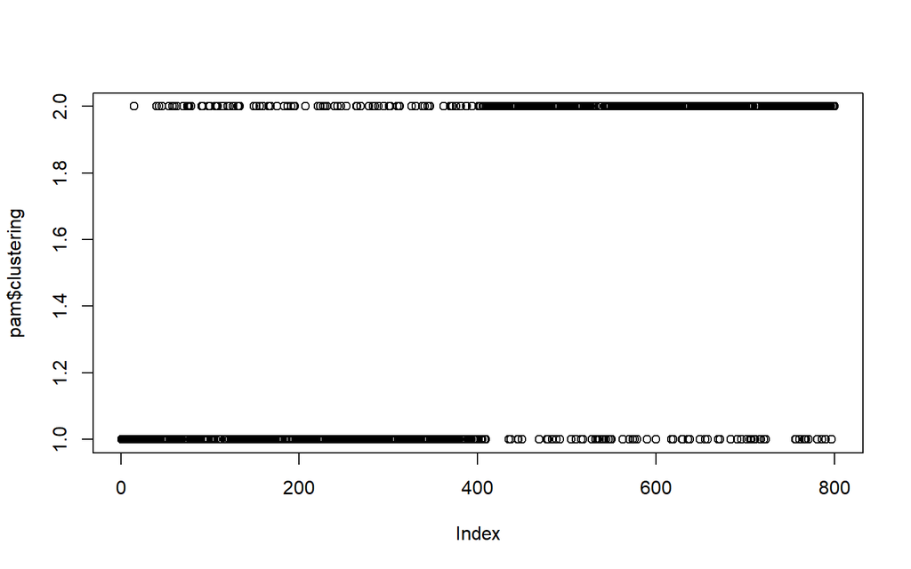

```
$`Matriz de confusão`
        base$grupo
predicao   1   2
       1 321  71
       2  79 329

$Acertos
    1     2
80.25 82.25
```

```r
MVpam("euclidean", BD, 2)
```

## 2.1.2 Método da distância Manhattan

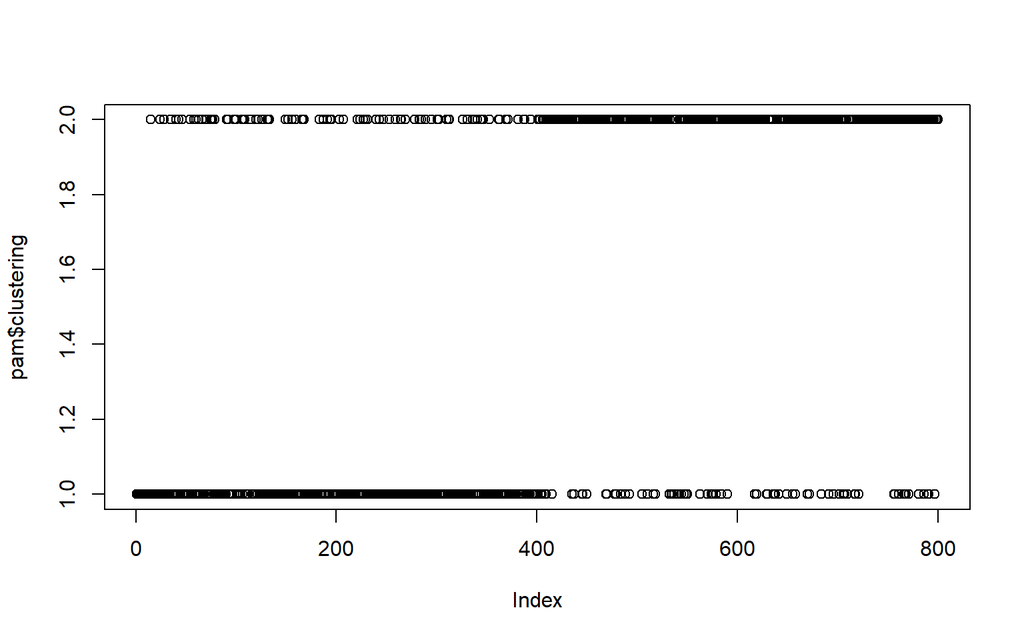

```
$`Matriz de confusão`
        base$grupo
predicao   1   2
       1 313  74
       2  87 326

$Acertos
    1     2
78.25 81.50
```

```r
MVpam("manhattan", BD, 2)
```

# 2.2. Análise de Clusters por métodos hierárquicos

## 2.2.1. Método de Ward.D com distância Euclideana

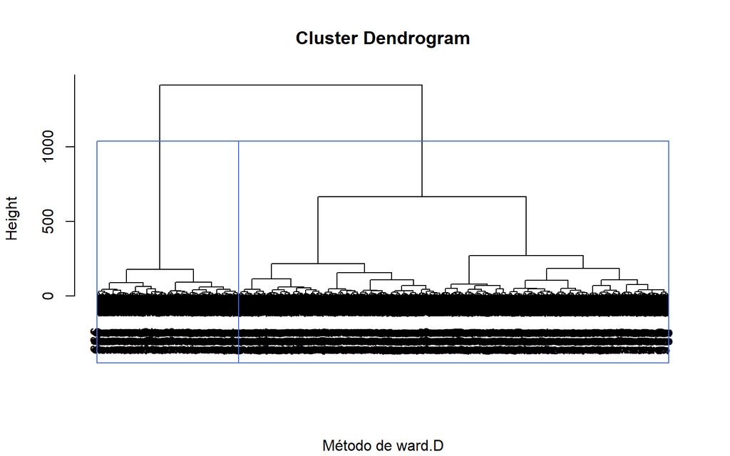

```
$`Matriz de confusão`
        base$grupo
predicao   1   2
       1 220 382
       2 180  18

$Acertos
   1    2
55.0  4.5
```

```r
MVcluster("ward.D", "euclidian", BD, 2)
```

## 2.2.2. Método de Ward.D com distância Manhattan

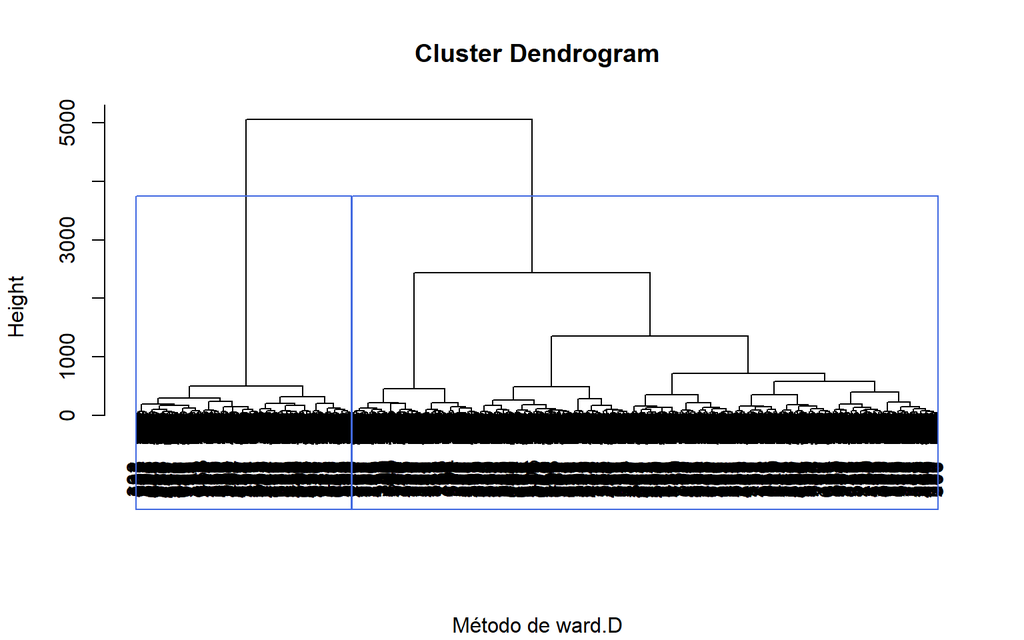

```
$`Matriz de confusão`
        base$grupo
predicao   1   2
       1 372 213
       2  28 187

$Acertos
    1     2
93.00 46.75
```

```r
MVcluster("ward.D", "manhattan", BD, 2)
```

## 2.2.3. Método de Single com distância Euclideana

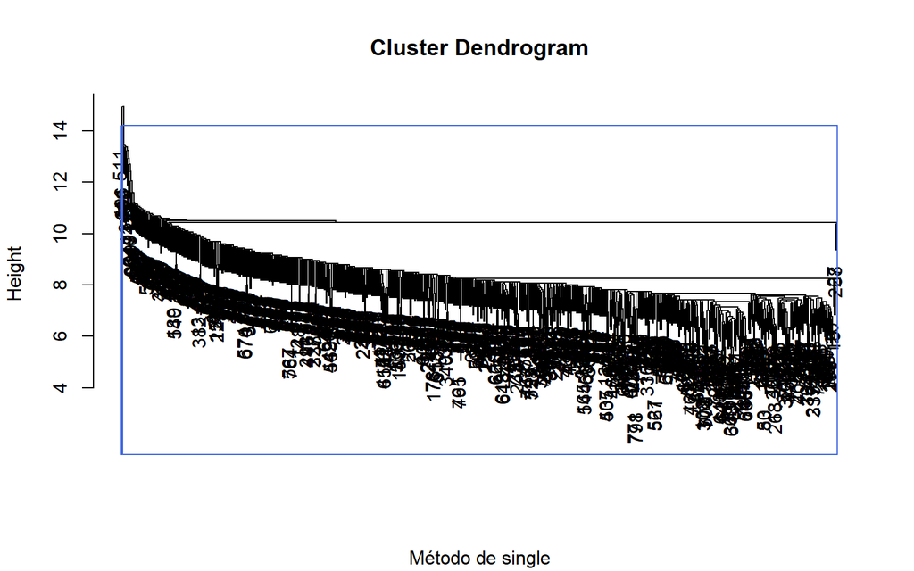

```
$`Matriz de confusão`
        base$grupo
predicao   1   2
       1 400 399
       2   0   1

$Acertos
     1      2
100.00   0.25
```

```r
MVcluster("single", "euclidian", BD, 2)
```

## 2.2.4. Método de Single com distância Manhattan

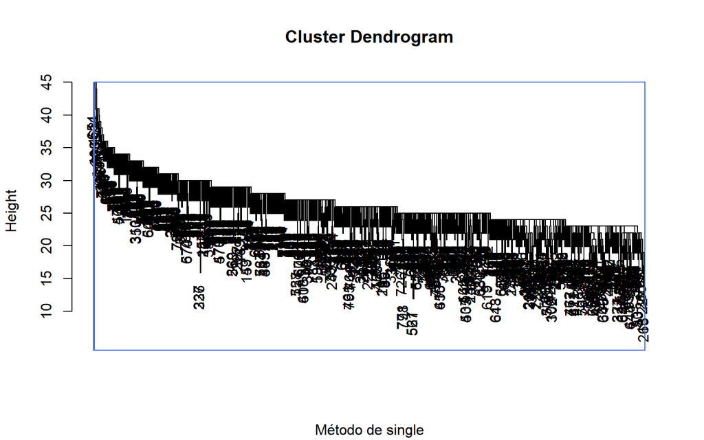

```
$`Matriz de confusão`
        base$grupo
predicao   1   2
       1 400 399
       2   0   1

$Acertos
     1      2
100.00   0.25
```

```r
MVcluster("single", "manhattan", BD, 2)
```

## 2.2.5. Método de Centroid com distância Euclideana

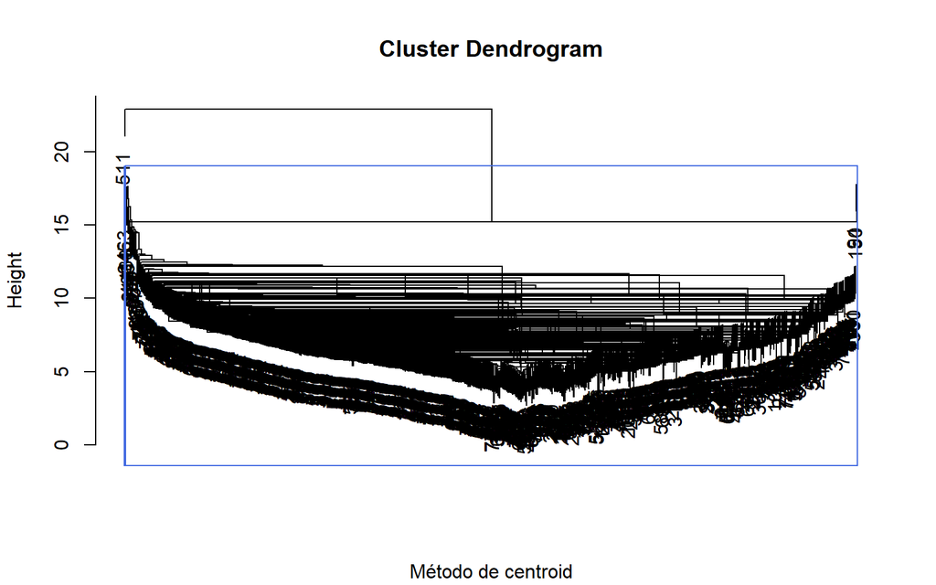

```
$`Matriz de confusão`
        base$grupo
predicao   1   2
       1 400 399
       2   0   1

$Acertos
     1      2
100.00   0.25
```

```r
MVcluster("centroid", "euclidian", BD, 2)
```

## 2.2.6. Método de Centroid com distância Manhattan

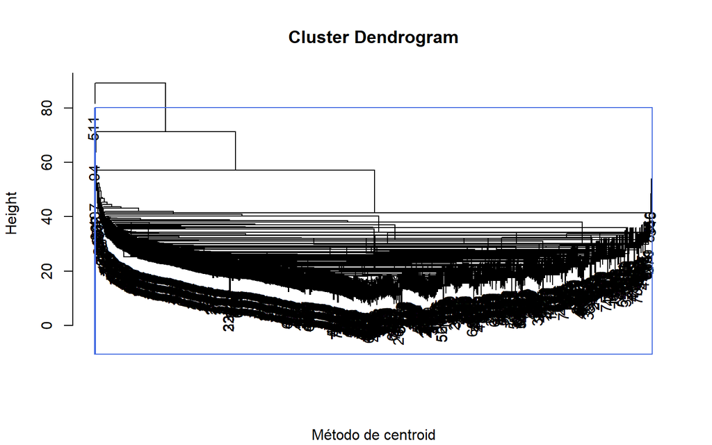

```
$`Matriz de confusão`
        base$grupo
predicao   1   2
       1 400 399
       2   0   1

$Acertos
     1      2
100.00   0.25
```

```r
MVcluster("centroid", "manhattan", BD, 2)
```

# 3. Análise de Discriminante e Análise Fatorial

## 3.1 Análise de Discriminante

Uma das condições requeridas para a relização da análise de descriminante é normalidade. Foi utilizado o método de Shapiro-Wilk e obteve-se :

```r
mvShapiroTest::mvShapiro.Test(as.matrix(BD[, -18]))$p.value
```

```
[1] 0.1664897
```

Ao nível de significância de 5% aceitamos H0, isso é, acredita-se que há normalidade dos dados.

```r
MVanalis_disc = function(base) {
    analise = MASS::lda(as.data.frame(select_if(base, is.numeric)), BD$grupo,
        CV = TRUE)
    plot(analise$class, col = "purple")
    predicao = analise$class
    classificacao = xtabs(~predicao + BD$grupo)
    acertos = diag(classificacao)/colSums(classificacao) * 100
    return(list(`Matriz de confusão` = classificacao, Acertos = acertos))
}
```

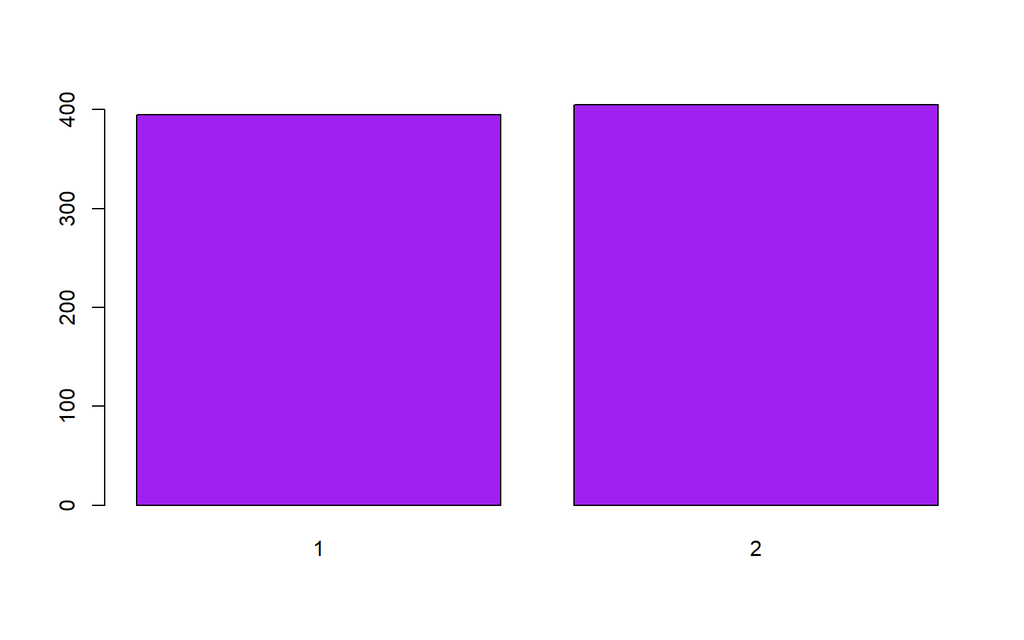

[output not shown]

```r
MVanalis_disc(BD)
```

## 3.2 Análise Fatorial

```r
analise_fat_1 = factanal(BD[, -18], factors = 11, rotation = "varimax", scores = "regression")

analise_fat_1$loadings
```

```
Loadings:
    Factor1 Factor2 Factor3 Factor4 Factor5 Factor6 Factor7 Factor8
Q1   0.120   0.189   0.190   0.117   0.105           0.878   0.257
Q2   0.196           0.238   0.149   0.146   0.134   0.281   0.862
Q3   0.191   0.188   0.124           0.113   0.915           0.111
Q4   0.369   0.196   0.171           0.167   0.347
Q5   0.250   0.118                   0.928   0.123           0.121
Q6           0.594           0.196   0.264
    Factor9 Factor10 Factor11
Q1   0.152
Q2
Q3           0.193
Q4   0.130   0.780
Q5
Q6           0.126
 [ reached getOption("max.print") -- omitted 11 rows ]

               Factor1 Factor2 Factor3 Factor4 Factor5 Factor6 Factor7
SS loadings      2.485   2.278   1.516   1.265   1.183   1.165   1.043
Proportion Var   0.146   0.134   0.089   0.074   0.070   0.069   0.061
Cumulative Var   0.146   0.280   0.369   0.444   0.513   0.582   0.643
               Factor8 Factor9 Factor10 Factor11
SS loadings      0.954   0.893    0.863    0.342
Proportion Var   0.056   0.053    0.051    0.020
Cumulative Var   0.699   0.752    0.803    0.823
```

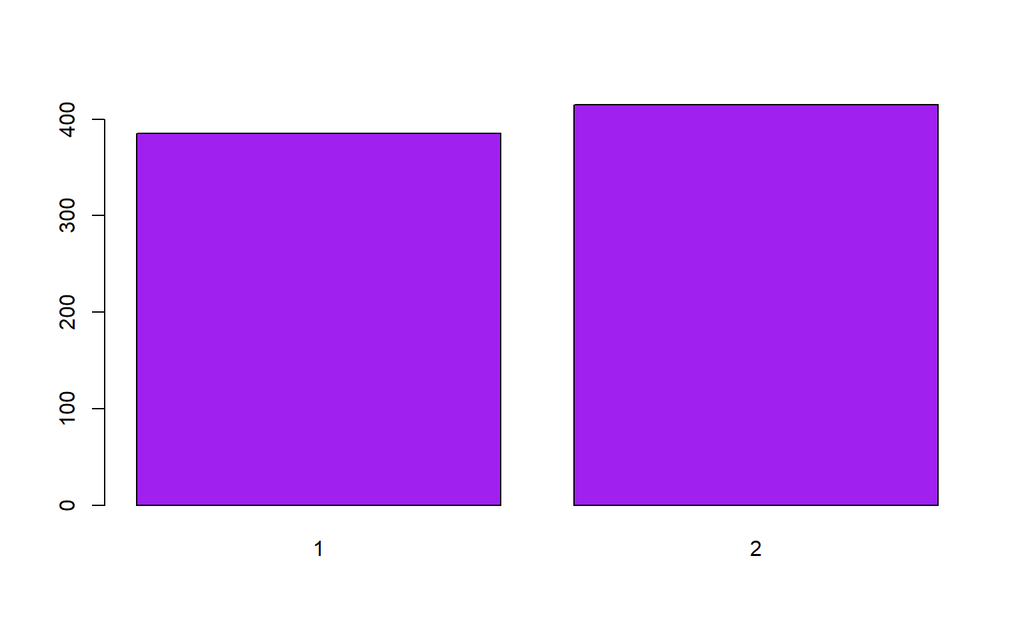

```
$`Matriz de confusão`
        BD$grupo
predicao   1   2
       1 329  56
       2  71 344

$Acertos
    1     2
82.25 86.00
```

```r
escores = analise_fat_1$scores

MVanalis_disc(as.data.frame(escores))
```

## 3.3 Análise Fatorial pelo critério de Kaiser (1958)

```r
fatores = eigen(cor(BD[, -18]))$values
fatores
```

```
 [1] 6.48269218 1.87101225 1.55580643 1.04224123 0.99830924 0.86808561
 [7] 0.68550157 0.62776367 0.52711756 0.47744365 0.42572148 0.40174277
[13] 0.34618387 0.26536356 0.21039201 0.13827407 0.07634884
```

```r
nfatores = length(fatores[fatores >= 1])
paste0(nfatores, " fatores são maiores ou iguais a 1")
```

```
[1] "4 fatores são maiores ou iguais a 1"
```

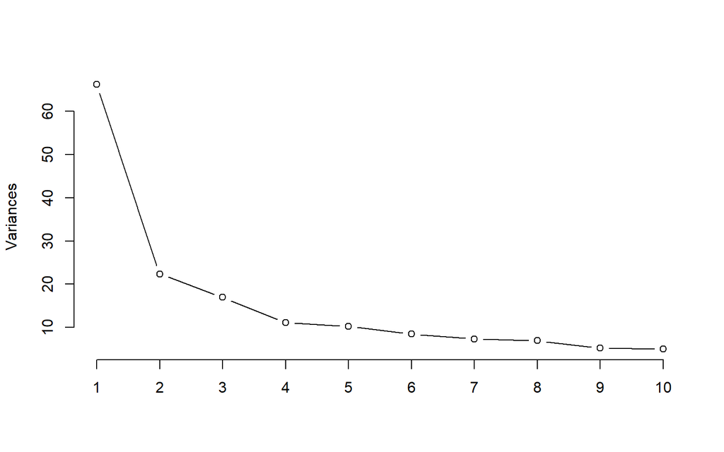

```r
comp_princ = prcomp(BD[, -18])
plot(comp_princ, type = "lines", main = "")
```

```r
analise_fat_2 = factanal(BD[, -18], factors = 4, rotation = "varimax", scores = "regression")

analise_fat_2$loadings
```

```
Loadings:
    Factor1 Factor2 Factor3 Factor4
Q1   0.200   0.505   0.280
Q2   0.307   0.484   0.121   0.183
Q3   0.256   0.173   0.187   0.930
Q4   0.550   0.289   0.126   0.455
Q5   0.456   0.191           0.186
Q6           0.184   0.542
Q7   0.302           0.772
Q8   0.186   0.110   0.970
Q9   0.785   0.140   0.182   0.271
Q10  0.827   0.293
Q11  0.574   0.339   0.229   0.124
Q12  0.255   0.563
Q13  0.213   0.612   0.143   0.134
Q14  0.387   0.674
Q15          0.645           0.158
Q16          0.622   0.230
Q17  0.639   0.140   0.295

               Factor1 Factor2 Factor3 Factor4
SS loadings      3.145   2.883   2.237   1.301
Proportion Var   0.185   0.170   0.132   0.077
Cumulative Var   0.185   0.355   0.486   0.563
```

```r
escores2 = analise_fat_2$scores
```

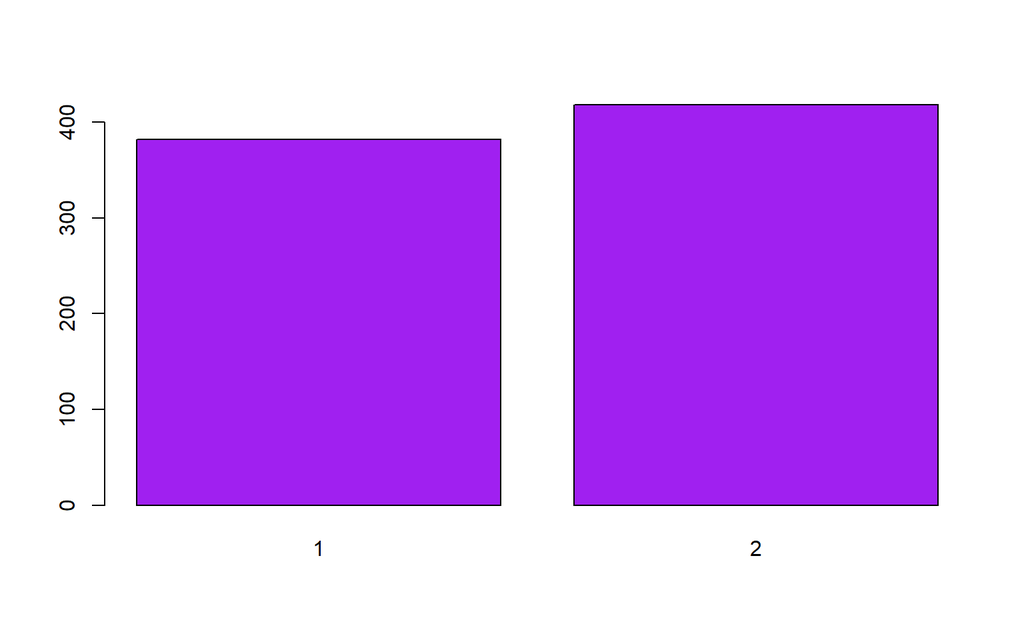

```
$`Matriz de confusão`
        BD$grupo
predicao   1   2
       1 317  65
       2  83 335

$Acertos
    1     2
79.25 83.75
```

```r
MVanalis_disc(as.data.frame(escores2))
```

# 4. Conclusões

Após a aplicação de alguns métodos de divisão dos dados em clusters, foi verificado que o método de Análise de Discriminante foi aquele que apresentou melhores resultados que os outros métodos. O método de análise de discriminante após a realização de análise fatorial apresentou um pouco mais de erros na previsão, porém vale ressaltar que neste método utiliza-se menos variáveis e obteve-se acertos de 79.25% de classificação para o grupo1 e 83.75% para o grupo2, o que é considerado ótimo.

Lyncoln Sousa de Oliveira

2019-12-16